### 1. House features

[5 points]

Data: *ames* in the **openintro** package

1. Create a frequency bar chart for the roof styles of the properties.

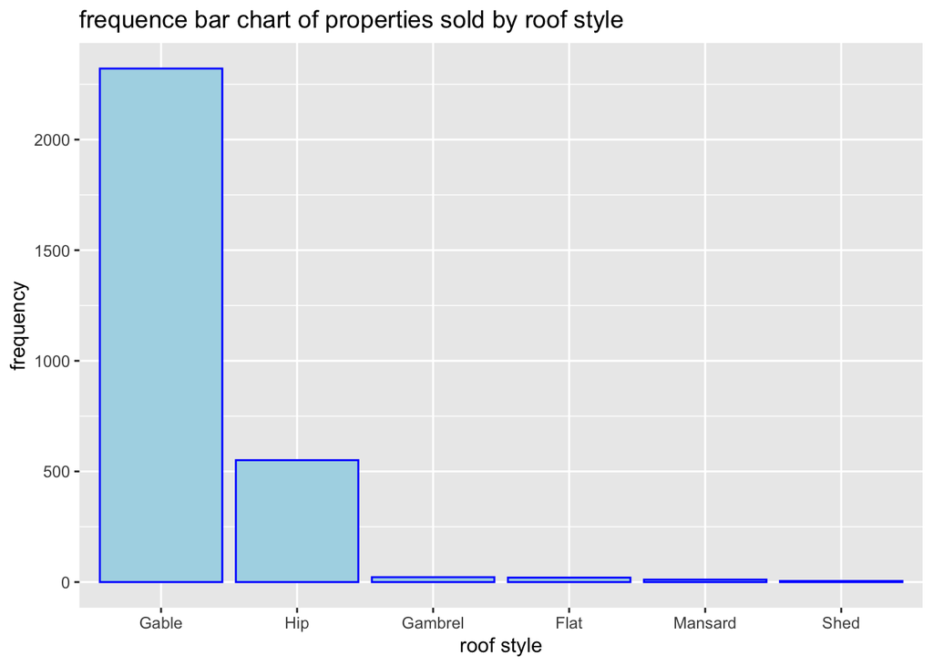

```r
ggplot(ames,aes(fct_infreq(Roof.Style)))+geom_bar(color='blue',fill='lightblue')+
  labs(x='roof style',y='frequency',
       title="frequence bar chart of properties sold by roof style")+
  theme()
```

2. Create a frequency bar chart for the variable representing the month in which the property was sold.

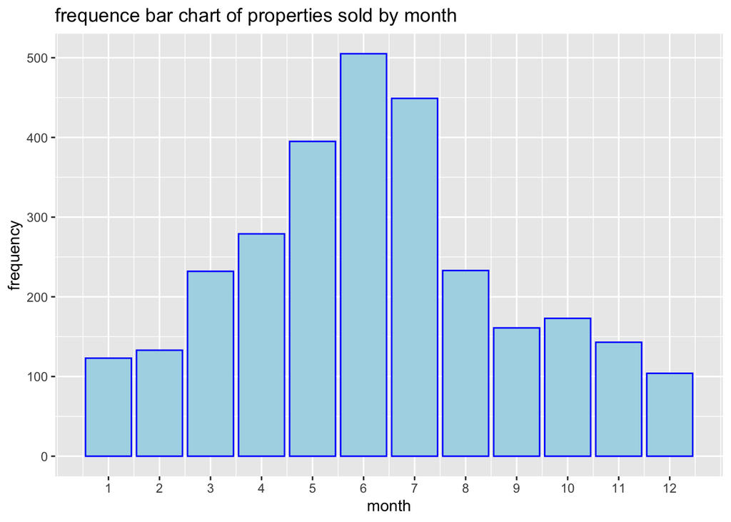

```r
ggplot(ames,aes(Mo.Sold))+geom_bar(color='blue',fill='lightblue')+
  scale_x_continuous(breaks = seq(1, 12, 1))+
  labs(x='month',y='frequency',
       title="frequence bar chart of properties sold by month")+
  theme()
```

3. List all the factor variables that have `"Ex" "Fa" "Gd" "Po" "TA"` as levels.

```r
fc <- c("Ex","Fa","Gd","Po","TA")
df <- names(ames %>%
 sapply(levels) %>%
 keep(function(x) {
   all(fc %in% x)}))
df<-df[df!="Bsmt.Exposure"]
df
```

```
## [1] "Exter.Cond"   "Bsmt.Qual"    "Bsmt.Cond"    "Heating.QC"   "Kitchen.Qual"
## [6] "Fireplace.Qu" "Garage.Qual"  "Garage.Cond"
```

Short Answer: We selected those variables that have exactly match to the five levels. d) Create faceted bar charts using `facet_wrap()` to display the frequency distribution of all variables from part c). (Hint: transform the data first with `pivot_longer()`)

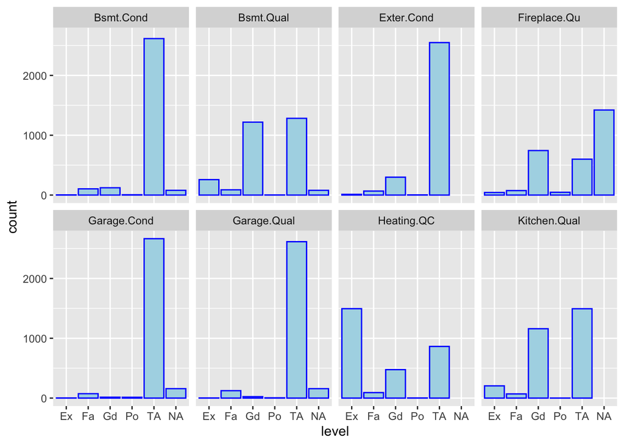

```r
ames[df] %>%
  rownames_to_column("observation") %>%
  pivot_longer(cols=!observation,names_to = "type",values_to = "level")%>%
  filter(level != ""|is.na(level)) %>%
  ggplot(aes(level))+geom_bar(color='blue',fill='lightblue')+
  facet_wrap(~type,ncol = 4)
```

Short Answer: Before plotting the data, we need to deal with the empty string in some variables.We first treated it as NA values but after reading the original package documentation, we noticed that NA does not mean missing,it means that certain things such as kitchen,basement,etc are not appearing in some properties. So we think NA also has the ordinal information and we treated it as lower than the Po(poor condition) and placed it as the last one. Then, we decided to remove all the empty strings in the variables because they represent missing entries. From the graph, we can tell that Bsmt.Cond,Exter.Cond,Garage.Qual,Garage.Cond,Fireplace.Qu, Kitchen.Qual are approximately left skewed and the remaining two are bimodal. ### 2. Pet names

[12 points]

Data: *seattlepets* in the **openintro** package

```r
dog <- filter(seattlepets,species=="Dog")
cat <- filter(seattlepets,species=="Cat")
dogcat <- filter(seattlepets, species %in% c("Dog","Cat"))
dogcat <- dogcat %>%
  count(animal_name,species,name='total') %>%
  pivot_wider(id_cols=animal_name,names_from = species,values_from = total) %>%
  rowwise() %>%
  mutate(total=sum(Cat,Dog,na.rm = TRUE),proportion=Dog/total,ratio=Dog/Cat) %>%
  ungroup() %>%
  arrange(desc(total))
dogcat
```

```
## # A tibble: 13,920 × 6
##    animal_name   Cat   Dog total proportion ratio
##    <chr>       <int> <int> <int>      <dbl> <dbl>
##  1 <NA>          406    76   482      0.158 0.187
##  2 Lucy          102   337   439      0.768 3.30
##  3 Charlie        81   306   387      0.791 3.78
##  4 Luna          111   244   355      0.687 2.20
##  5 Bella          82   249   331      0.752 3.04
##  6 Max            83   186   269      0.691 2.24
##  7 Daisy          40   221   261      0.847 5.52
##  8 Molly          54   186   240      0.775 3.44
##  9 Jack           65   167   232      0.720 2.57
## 10 Lily           86   146   232      0.629 1.70
## # … with 13,910 more rows
```

Short Answer: Before starting the question, we created a dataframe containing the animal_name and the count of each name for dog and cat, the total number of names, the proportion and ratio. The proportion is calculated by the dog/total and the ratio is calculated by the dog/cat.Also, we used na.rm function to deal with NA values in calculation. a) Create separate Cleveland dot plots for the 30 most popular dog names and 30 most popular cat names.

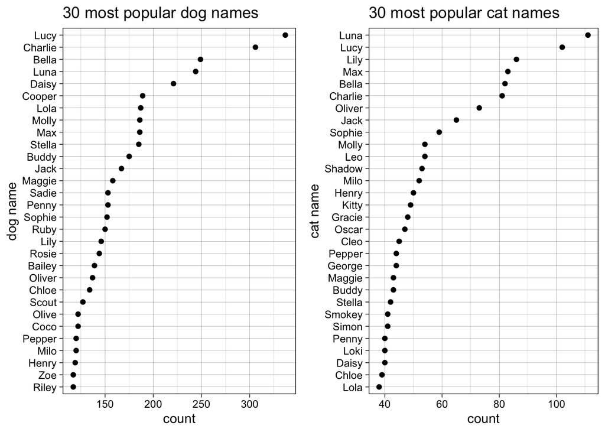

```r
dc <- filter(dogcat,is.na(animal_name)==FALSE)
g1 <- dc %>%
  arrange(desc(Dog)) %>%
  slice_head(n=30) %>%
  ggplot(aes(Dog,fct_reorder(animal_name,Dog))) +geom_point()+
  ggtitle("30 most popular dog names")+
  labs(y="dog name",x="count")+
  theme_linedraw()
g2 <- dc %>%
  arrange(desc(Cat)) %>%
  slice_head(n=30) %>%
  ggplot(aes(Cat,fct_reorder(animal_name,Cat))) +geom_point()+
  ggtitle("30 most popular cat names")+
  labs(y="cat name",x="count")+
  theme_linedraw()
grid.arrange(g1, g2, nrow = 1)
```

Short Answer: Before plotting the 30 most popular names for dog and cat, we first removed the NA in the animal name because it has no meaning and it doesn’t make sense at all to talk about NA as animal name, so we removed it from the dataframe. Then we sort the dataframe by the count of dog and cat and then plot the graph. b) Use a Cleveland dot plot to display the 30 names that are the most “dog” measured by the proportion of all animals with that name that are dogs. (You can remove goat and pig names from the dataset.) *Clearly state any decisions you make about what to include and not include and explain your reasoning.*

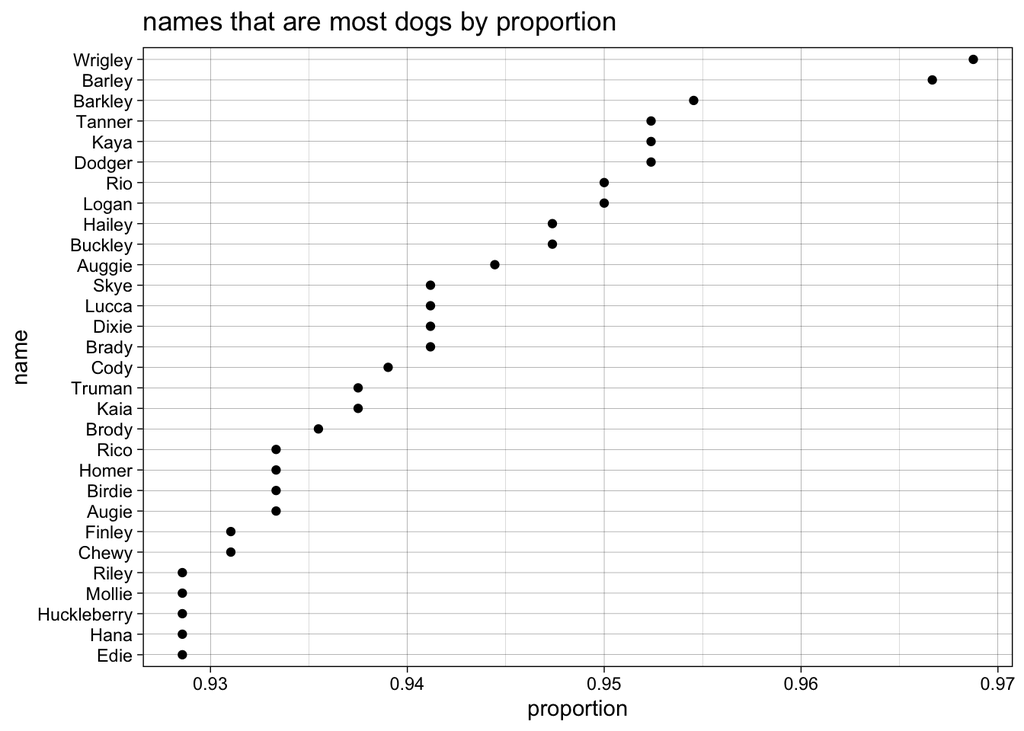

```r
dc %>%
  filter(proportion!=1) %>%
  arrange(desc(proportion)) %>%
  slice_head(n=30) %>%
  ggplot(aes(proportion,fct_reorder(animal_name,proportion))) +geom_point()+
  theme_linedraw() +
  ggtitle("names that are most dogs by proportion")+
  labs(y="name",x="proportion")
```

Short Answer: To determine the 30 names that are most dog names, we will be using the proportion which is already added to the dogcat dataframe at the beginning to help determine that. Then, I removed all the animal names that have proportions equal to 1 because the question says to find names that are the most “dog” measured by the proportion of “all” animals (cat+dog), those names are not shared by both dog and cat.In other word, I only include the names that are shared by both dog and cat. Then I sorted the dataframe by the proportion in decreasing order and then plot the 30 most popular names with the corresponding proportion.

3. Find the 30 most popular names for dogs and cats combined, and create a multidot Cleveland dot plot showing the counts for dogs, cats, and total for each of these 30 names. (One color for dogs, one color for cats, one color for total.) Order the dots by the total count.

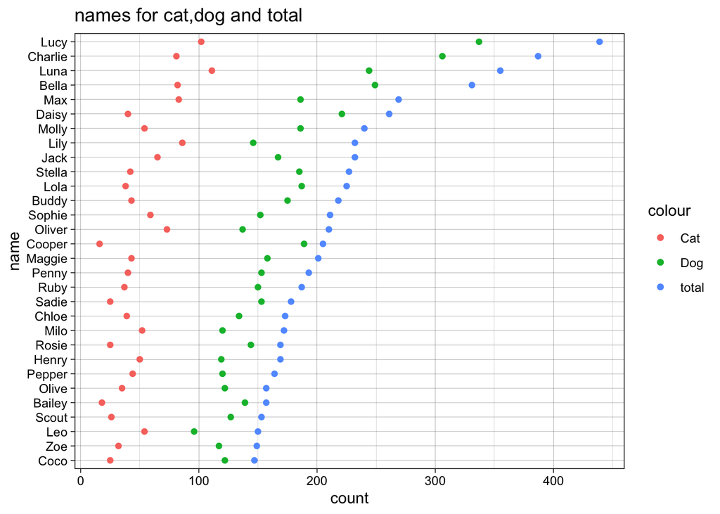

```r
dc %>%
  arrange(desc(total)) %>%
  slice_head(n=30) %>%
  ggplot()+
  geom_point(aes(total,fct_reorder(animal_name,total),col='total'))+
  geom_point(aes(Dog,animal_name,col='Dog'))+
  geom_point(aes(Cat,animal_name,col='Cat'))+
  theme_linedraw() +
  ggtitle("names for cat,dog and total")+
  labs(x='count',y='name')
```

Short Answer: From the graph, we can tell that names with the highest total count are for both cat and dog.

4. Create a scatterplot of popular cat names vs. popular dog names. Clearly some names are more “dog” names and some are more “cat” names. Decide on a metric for defining what is a “dog” name, a “cat” name, and a “neutral” name and state it explicity. What is your metric?

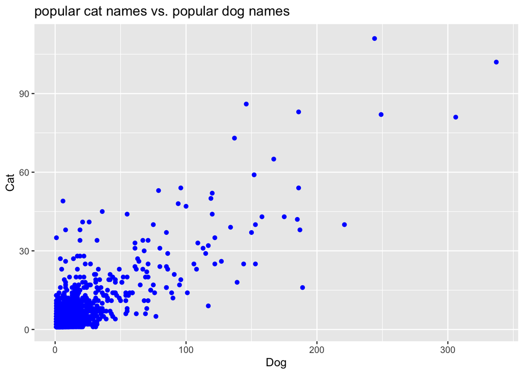

```r
dc %>%
  ggplot(aes(Dog,Cat))+geom_point(col='blue')+
  ggtitle("popular cat names vs. popular dog names")
```

```r
quantile(dc$ratio,na.rm = TRUE)
```

```
##          0%         25%         50%         75%        100%
##  0.02857143  1.00000000  1.45454545  3.00000000 31.00000000
```

```r
df <- dc %>%
  mutate(species=ifelse(is.na(Cat)==TRUE,"Cat","Dog"))
df$species[df$ratio>=1&df$ratio<=3] <-"neutral"
df$species[df$ratio>3] <-"Dog"
df$species[df$ratio<1] <-"Cat"
df
```

```
## # A tibble: 13,919 × 7
##    animal_name   Cat   Dog total proportion ratio species
##    <chr>       <int> <int> <int>      <dbl> <dbl> <chr>
##  1 Lucy          102   337   439      0.768  3.30 Dog
##  2 Charlie        81   306   387      0.791  3.78 Dog
##  3 Luna          111   244   355      0.687  2.20 neutral
##  4 Bella          82   249   331      0.752  3.04 Dog
##  5 Max            83   186   269      0.691  2.24 neutral
##  6 Daisy          40   221   261      0.847  5.52 Dog
##  7 Molly          54   186   240      0.775  3.44 Dog
##  8 Jack           65   167   232      0.720  2.57 neutral
##  9 Lily           86   146   232      0.629  1.70 neutral
## 10 Stella         42   185   227      0.815  4.40 Dog
## # … with 13,909 more rows
```

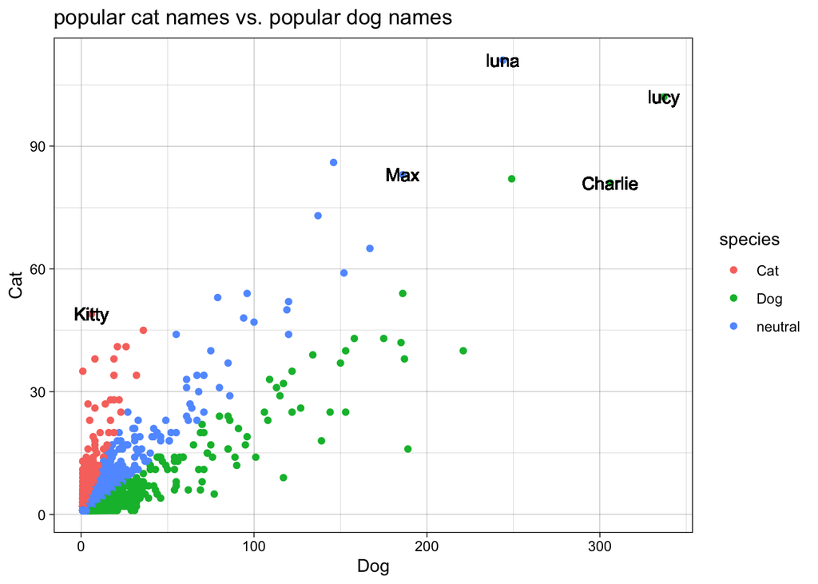

```r
df %>%
  ggplot(aes(Dog,Cat))+geom_point(aes(col=species))+
  ggtitle("popular cat names vs. popular dog names")+
  theme_linedraw() +
  geom_text(aes(337,102,label="lucy"))+
  geom_text(aes(306,81,label="Charlie"))+
  geom_text(aes(244,111,label="luna"))+
  geom_text(aes(186,83,label="Max"))+
  geom_text(aes(6,49,label="Kitty"))
```

[6 points]

Data: *ames* in the **openintro** package

For all, adjust parameters to the levels that provide the best views of the data.

Draw four plots of `price` vs. `area` with the following variations:

1. Scatterplot – adjust point size and `alpha`.

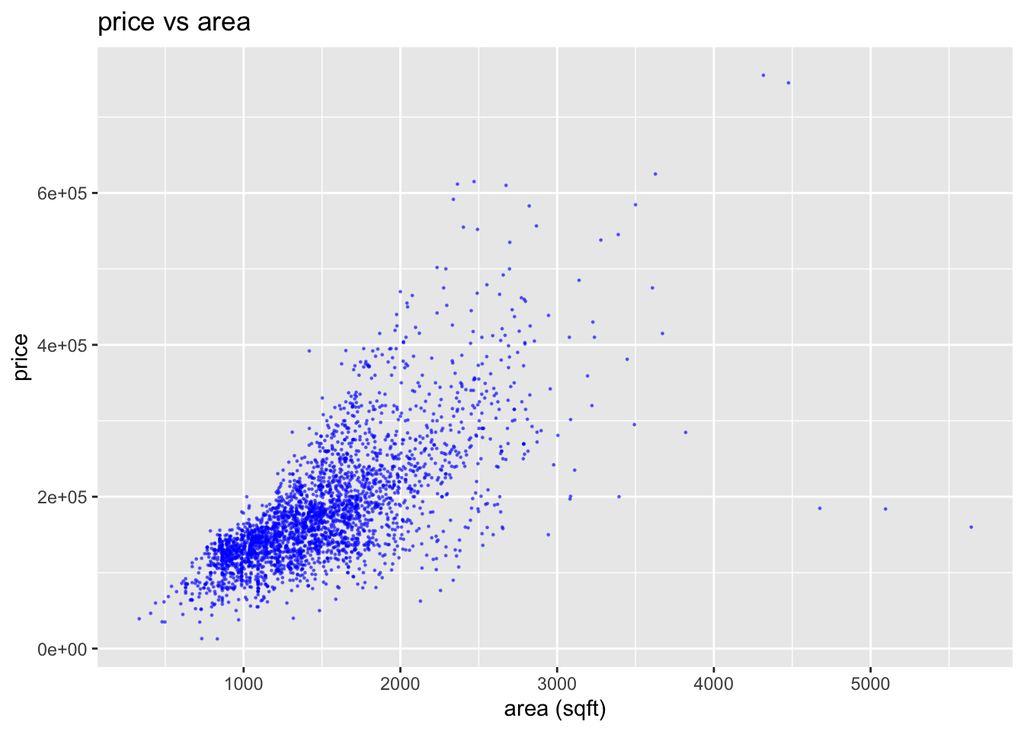

```r
ggplot(ames,aes(area,price))+geom_point(color='blue',alpha=.5,size=.2)+
  labs(x='area (sqft)',y='price',title='price vs area')
```

2. Scatterplot with density contour lines

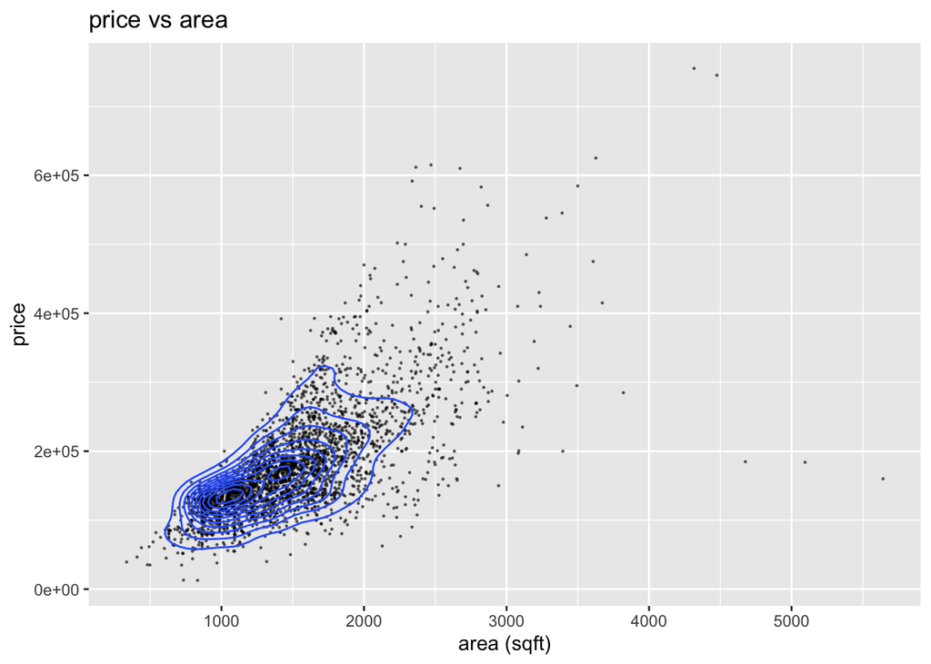

```r
ggplot(ames,aes(area,price))+geom_point(size=.2,alpha=.5)+geom_density_2d()+
  labs(x='area (sqft)',y='price',title='price vs area')
```

3. Hexagonal heatmap of bin counts

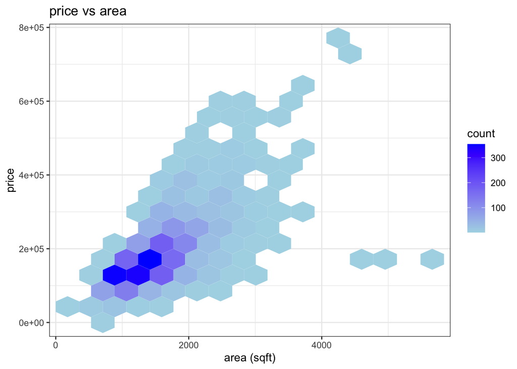

```r
ggplot(ames,aes(area,price))+geom_hex(bins=15)+
  scale_fill_gradient(low='lightblue',high='blue')+theme_bw()+
  labs(x='area (sqft)',y='price',title='price vs area')
```

4. Square heatmap of bin counts

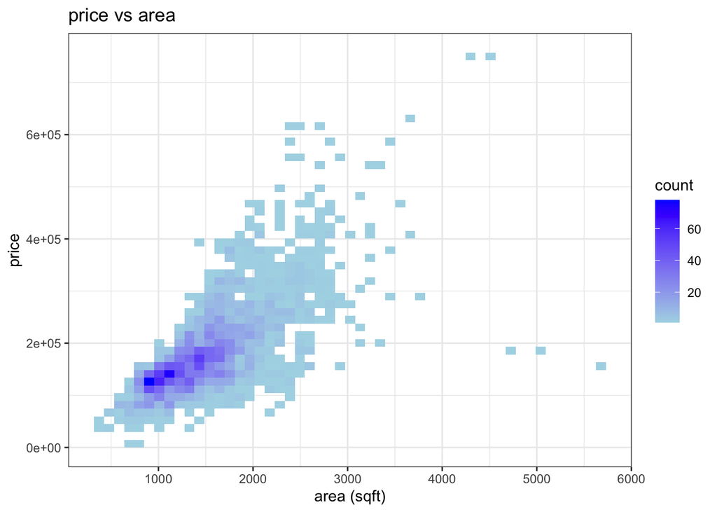

```r
ggplot(ames,aes(area,price))+geom_bin_2d(bins=50)+
  scale_fill_gradient(low='lightblue',high='blue')+theme_bw()+
  labs(x='area (sqft)',y='price',title='price vs area')
```

5. Describe noteworthy features of the data, using the “Movie ratings” example on page 82 (last page of Section 5.3) as a guide.

Short Answer: 1. The general trend is that houses with larger area have higher prices except outliers above 4000 sqft. 2. The most popular houses are between the $100k$ and $200k$ and area is between approximately 750 to 2000 sqft. 3. The largest count of houses have area between 750 and 1250 sqft and price is from $100k$ to $175k$. 4. The relationship of area vs price is close to the linear relationship.As the area increases, the price increases. 5. There are few houses with price above $400k$ and most samples are below $400k$.Similarly, most of the sample data is below the 3000sqft and above 500sqft. 6. There are no small house with a large price and nearly no house has a large area with a small price. ### 4. Correlations

[7 points]

Data: *ames* in the **openintro** package

1. Recreate the scatterplot from part 3 (`price` vs. `area`) this time faceting on `Neighborhood` (use `facet_wrap()`. Add best fitting lines and sort the facets by the slope of the best fitting line from low to high. (Use `lm()` to get the slopes.)

```r
ames_new <- ames
neigh_sort <- ames_new %>%
  group_by(Neighborhood) %>%
  summarise(slope=lm(price~area)$coefficients[[2]]) %>%
  arrange(slope)
neigh_sort
```

```
## # A tibble: 28 × 2
##    Neighborhood slope
##    <fct>        <dbl>
##  1 Blueste      -14.1
##  2 NPkVill       25.2
##  3 Veenker       27.9
##  4 SWISU         35.6
##  5 Sawyer        35.9
##  6 MeadowV       37.3
##  7 Edwards       40.0
##  8 ClearCr       42.7
##  9 NAmes         54.6
## 10 BrDale        54.9
## # … with 18 more rows
```

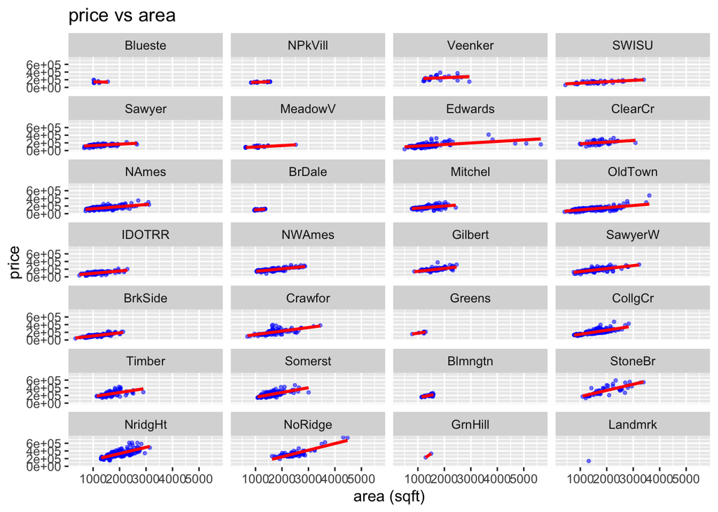

```r
ames_new$Neighborhood <- factor(ames_new$Neighborhood,levels = neigh_sort$Neighborhood)
ggplot(ames_new,aes(area,price))+
  geom_point(color='blue',alpha=.5,size=.8)+
  geom_smooth(method = "lm",col = "red")+
  facet_wrap(~Neighborhood,ncol = 4)+
  labs(x='area (sqft)',y='price',title='price vs area')
```

2. Is the slope higher in neighborhoods with higher mean housing prices? Present graphical evidence and interpret in the context of this data.

```r
ames1 <- ames
ames1 <- ames1 %>%
  group_by(Neighborhood) %>%
  summarise(slope=lm(price~area)$coefficients[[2]],mean_price=mean(price)) %>%
  arrange(slope)
ames1
```

```
## # A tibble: 28 × 3
##    Neighborhood slope mean_price
##    <fct>        <dbl>      <dbl>
##  1 Blueste      -14.1    143590
##  2 NPkVill       25.2    140711.
##  3 Veenker       27.9    248315.
##  4 SWISU         35.6    135072.
##  5 Sawyer        35.9    136751.
##  6 MeadowV       37.3     95756.
##  7 Edwards       40.0    130843.
##  8 ClearCr       42.7    208662.
##  9 NAmes         54.6    145097.
## 10 BrDale        54.9    105608.
## # … with 18 more rows
```

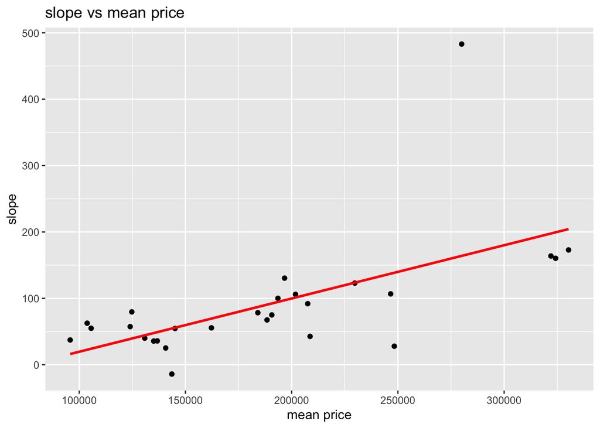

```r
ggplot(ames1,aes(mean_price,slope))+geom_point()+
  geom_smooth(method = "lm", col = "red",se=FALSE)+
  labs(x='mean price',y='slope',title='slope vs mean price')
```

Short Answer: The steeper the slope the higher the mean housing prices. The mean price of most houses fall between 100k and 250k and the slope is between 50 and 150. From the graph, we can tell that it’s likely a upward trend but with some variations. So the higher the mean housing price, the higher the slope is.

3. Repeat parts a) with the following adjustment: order the faceted plots by $R^2$ from the linear regression of `price` on `area` by `Neighborhood`. Is the $R^2$ higher in neighborhoods with higher mean housing prices? Are the results the same for slope and $R^2$? Explain using examples from the graphs.

```r
ames2 <- ames
rs <- ames2 %>%
  group_by(Neighborhood) %>%
  summarise(r_squared=summary(lm(price~area))[['r.squared']],mean_price=mean(price)) %>%
  arrange(r_squared)
arrange(rs,mean_price)
```

```
## # A tibble: 28 × 3
##    Neighborhood r_squared mean_price
##    <fct>            <dbl>      <dbl>
##  1 MeadowV          0.384     95756.
##  2 IDOTRR           0.471    103753.
##  3 BrDale           0.426    105608.
##  4 OldTown          0.458    123992.
##  5 BrkSide          0.651    124756.
##  6 Edwards          0.279    130843.
##  7 SWISU            0.455    135072.
##  8 Sawyer           0.304    136751.
##  9 Landmrk          0        137000
## 10 NPkVill          0.451    140711.
## # … with 18 more rows
```

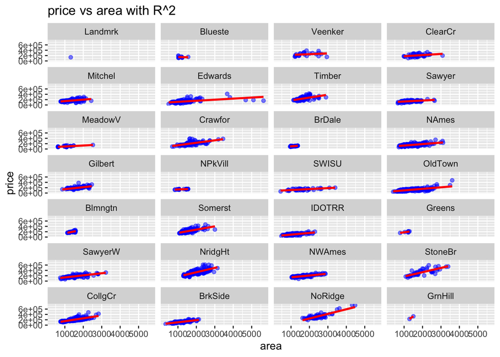

```r
ames2$Neighborhood <- factor(ames2$Neighborhood,levels=rs$Neighborhood)
ggplot(ames2,aes(area,price))+
  geom_point(color='blue',alpha=.5)+
  geom_smooth(method = "lm", col = "red")+
  facet_wrap(~Neighborhood,ncol = 4)+
  ggtitle("price vs area with R^2")
```

[figure not shown]

```r
ggplot(rs,aes(mean_price,r_squared))+geom_point()+
  geom_smooth(method = "lm", col = "red",se=FALSE)+
  labs(x='area (sqft)',y='price',title=' r squared vs mean price')+
  geom_text(aes(label='A',125000,0.75))+
  geom_text(aes(label='B',248314.58,0.1))
```

Short Answer: From the graph, it is likely to have an weak upward trend with great variations. The higher mean price doesn’t lead to higher R squared. For example,the point A and B on the graph. B has higher mean price than A but the r_squared of B is lower than that of A. So the result for R square is different for the slope.